# What Drives the Price of a Stay?

STAT 253 Group Assignment 1

Author

Wethu Mhlanga, Providence Thusabantu, Rukhshona Jalilova

Published

October 23, 2026

# 1. Key Takeaways

This analysis investigated how well listing features predict Airbnb nightly prices in New York City and which characteristics are associated with higher prices. We analyzed a random sample of 5,000 listings priced above $0 and below $1,000 per night, using LASSO regression, five-neighbor imputation of missing values, and a 10-fold cross-validation. While there were many predictors to consider we plotted just a few in Figure 1 and 2 to explore relationships before modeling.

Figure 1 shows that location matters, though only partly. Manhattan listings have the highest typical prices (median of roughly $145 per night), followed by Brooklyn (about $95), with the Bronx being the lowest (about $65). However, the price distributions overlap within the boroughs, and every borough includes listings that are outliers. So we can conclude that borough provides useful pricing context but cannot explain a listing’s price on its own.

Figure 2 shows that room type and capacity are also important. Entire homes generally cost more than private rooms, with the latter costing more than shared rooms. Prices tend to increase with the number of guests total accommodated, particularly for entire homes with prices ranging from roughly $130-150 for one guest to about $500 for sixteen. Still, the varying spread of prices at similar capacities shows that room type and size alone do not fully explain price differences.

For otherwise similar listings, private and shared rooms were associated with prices approximately $54 and $57 lower than entire homes, and a Manhattan location with a roughly $40 premium relative to the Bronx. Each additional bathroom (about $30), bedroom (about $22), and accommodated guest (about $16) was associated with higher prices.

We recommend using these estimates as reference points when judging whether a listing’s price is reasonable for its location, room type, and size. Some limitations to recognise from this report were: 1) listings of $1,000 or more were excluded, 2) missing values were estimated and lastly, 3) these estimates reflect associations not causality. Moreover, the model assumes that each feature has a linear relationship with price. Finally, this model also doesn’t account for photos and furnishing, which are vital characteristics when booking an Airbnb.

# 2. Technical details

```r
# Import original data
listings <- read.csv("https://ajohns24.github.io/data/NYC_airbnb_kaggle.csv")
nbhd     <- read.csv("https://ajohns24.github.io/data/NYC_nbhd_kaggle.csv")

# Wrangle this into the final airbnb data
set.seed(253)
airbnb <- listings %>%
  filter(price > 0, price < 1000) %>%
  sample_n(size = 5000) %>%
  rename(neighbourhood = neighbourhood_cleansed) %>%
  left_join(nbhd) %>%
  select(-neighbourhood, -amenities, -host_response_rate, -calendar_updated)

# Data wrangling and removign columns
airbnb_model <- airbnb %>%
  select(-id, -square_feet)
```

The main obstacle we came across while working with this dataset was the missing data. One of the columns which is square_feet was missing more that 4900 out of 5000 rows, hence why we removed it from the airbnb_model because it was not giving us any significant data. However, since square_feet wasn’t the only column with missing data, to address the remaining missing values across other predictors without discarding valuable observations, we implemented $K$-nearest neighbors imputation with five neighbors within our pre-processing recipe. Continuous missing features were estimated using the mean values of a listing’s five most similar neighbors, whereas categorical variables were imputed using the neighbor mode. Imputation was performed within each cross-validation fold so that held-out listings never informed the imputed values.

**Exploratory Data Analysis**

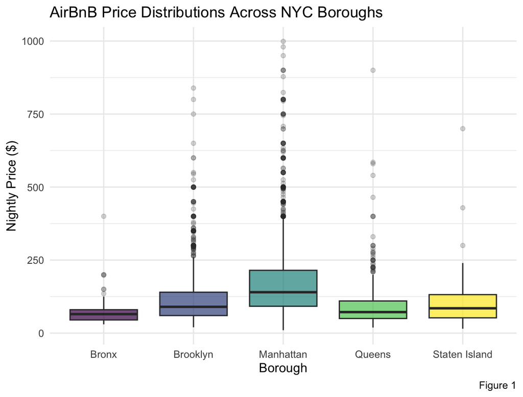

```r
# Plot 1: Price Distributions Across Neighborhood Groups (Boroughs)
ggplot(airbnb_model, aes(x = neighbourhood_group, y = price, fill = neighbourhood_group)) +
  geom_boxplot(alpha = 0.7, outlier.alpha = 0.2) +
  labs(
    title = "AirBnB Price Distributions Across NYC Boroughs",
    x = "Borough",
    y = "Nightly Price ($)",
    caption = "Figure 1"
  ) +
  theme_minimal() +
  theme(legend.position = "none") +
  scale_fill_viridis_d()
```

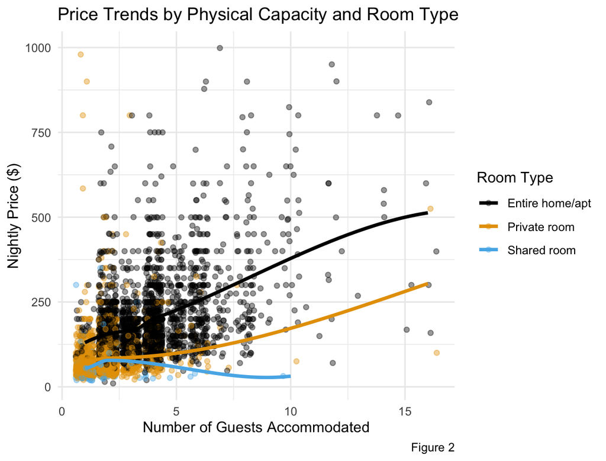

```r
# Plot 2: Predictors used (2): accommodation capacity, roomtype
ggplot(airbnb_model, aes(x = accommodates, y = price, color = room_type)) +
  geom_point(alpha = 0.4, position = "jitter") +
  geom_smooth(method = "loess", se = FALSE, size = 1.2) +
  labs(
    title = "Price Trends by Physical Capacity and Room Type",
    x = "Number of Guests Accommodated",
    y = "Nightly Price ($)",
    color = "Room Type",
    caption = "Figure 2"
  ) +
  theme_minimal()
```

**Model Specification and Tuning**

Because rental listings feature naturally correlated characteristics such as room count, bathroom count, and overall guest capacity, standard linear regression risks variance inflation due to multicollinearity. To overcome this limitation, we selected LASSO regression, an L1-regularized linear model. LASSO applies a penalty parameter that shrinks uninformative coefficient estimates toward zero, automatically zeroing out redundant features to deliver both predictive precision and parsimonious interpretability. We established a regularized grid search across 50 penalty values ranging from 0.001 to 10 on a logarithmic scale, evaluating model accuracy through 10-fold cross-validated Mean Absolute Error.

```r
# Define model specification
airbnb_lasso_spec <- linear_reg() |>
  set_mode("regression") |>
  set_engine("glmnet") |>
  set_args(mixture = 1, penalty = tune())

# Define recipe preprocessing steps
airbnb_variable_recipe <- recipe(price ~ ., data = airbnb_model) |>
  step_string2factor(all_nominal_predictors()) |>
  step_impute_knn(all_predictors(), neighbors = 5) |>
  step_dummy(all_nominal_predictors())

# Bundle into workflow
airbnb_lasso_workflow <- workflow() |>
  add_recipe(airbnb_variable_recipe) |>
  add_model(airbnb_lasso_spec)

# Tune model over cross-validation grid
set.seed(253)
airbnb_lasso_models <- airbnb_lasso_workflow |>
  tune_grid(
    grid = grid_regular(penalty(range = c(-3, 1)), levels = 50),
    resamples = vfold_cv(airbnb_model, v = 10),
    metrics = metric_set(mae)
  )
```

**Tuning Evaluation and Penalty Selection**

We evaluated 50 regularized penalty values ($\lambda$ between $[0.001, 10]$) on a logarithmic scale across 10-fold cross-validation using Mean Absolute Error (MAE) as our evaluation metric.

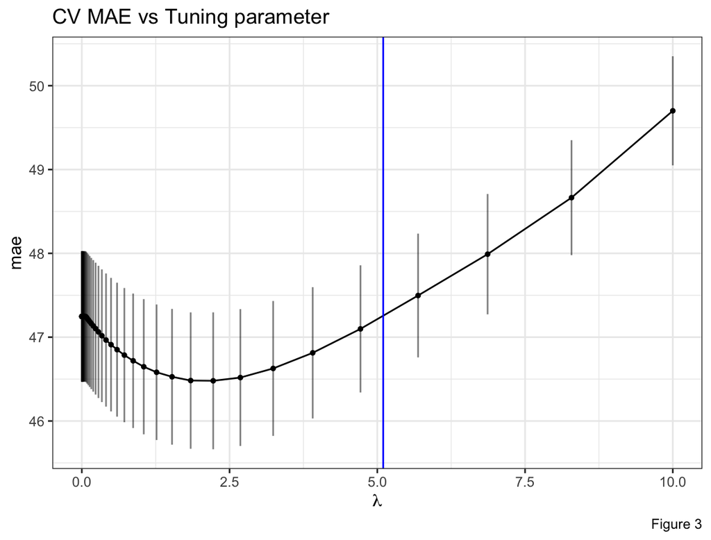

```r
# Select optimal penalty parameter
best_penalty <- airbnb_lasso_models %>%
  select_best(metric = "mae")

collect_metrics(airbnb_lasso_models) |>
  filter(penalty == best_penalty$penalty)
## # A tibble: 1 × 7
##   penalty .metric .estimator  mean     n std_err .config
##     <dbl> <chr>   <chr>      <dbl> <int>   <dbl> <chr>
## 1    2.22 mae     standard    46.5    10   0.816 pre0_mod42_post0

# Plot cross-validation results
autoplot(airbnb_lasso_models) +
  scale_x_continuous() +
  xlab(expression(lambda)) +
  geom_errorbar(data = collect_metrics(airbnb_lasso_models),
                aes(x = penalty, ymin = mean - std_err, ymax = mean + std_err),
                alpha = 0.5)+
  labs(
    title = "CV MAE vs Tuning parameter",
    caption = "Figure 3"
  ) +
  geom_vline(xintercept = 5.1, color = "blue")
```

```r
parsimonious_penalty <- airbnb_lasso_models |>
  select_by_one_std_err(metric = "mae", desc(penalty))

collect_metrics(airbnb_lasso_models) |>
  filter(penalty == parsimonious_penalty$penalty)
## # A tibble: 1 × 7
##   penalty .metric .estimator  mean     n std_err .config
##     <dbl> <chr>   <chr>      <dbl> <int>   <dbl> <chr>
## 1    4.71 mae     standard    47.1    10   0.758 pre0_mod46_post0
```

```r
# Finalize workflow and fit full model using best penalty
airbnb_final_1_lasso <- airbnb_lasso_workflow |>
  finalize_workflow(parameters = best_penalty) |>
  fit(data = airbnb_model)

airbnb_final_1_lasso %>%
  tidy() %>%
  filter(estimate != 0) %>%
  arrange(desc(abs(estimate)))
## # A tibble: 25 × 3
##    term                              estimate penalty
##    <chr>                                <dbl>   <dbl>
##  1 (Intercept)                       -30940.     2.22
##  2 longitude                           -418.     2.22
##  3 property_type_Timeshare               90.0    2.22
##  4 room_type_Shared.room                -76.0    2.22
##  5 neighbourhood_group_Staten.Island    -74.2    2.22
##  6 room_type_Private.room               -57.2    2.22
##  7 property_type_Condominium             46.4    2.22
##  8 bathrooms                             35.2    2.22
##  9 neighbourhood_group_Manhattan         35.1    2.22
## 10 property_type_Loft                    26.6    2.22
## # ℹ 15 more rows

# Finalize workflow and fit full model using parsimonious penalty
airbnb_final_1_lasso <- airbnb_lasso_workflow |>
  finalize_workflow(parameters = parsimonious_penalty) |>
  fit(data = airbnb_model)

# View non-zero coefficient estimates
airbnb_final_1_lasso %>%
  tidy() %>%
  filter(estimate != 0) %>%
  arrange(desc(abs(estimate)))
## # A tibble: 17 × 3
##    term                                  estimate penalty
##    <chr>                                    <dbl>   <dbl>
##  1 (Intercept)                       -22898.         4.71
##  2 longitude                           -310.         4.71
##  3 room_type_Shared.room                -57.4        4.71
##  4 room_type_Private.room               -53.6        4.71
##  5 neighbourhood_group_Manhattan         39.8        4.71
##  6 bathrooms                             29.8        4.71
##  7 property_type_Timeshare               28.7        4.71
##  8 property_type_Condominium             27.4        4.71
##  9 bedrooms                              21.7        4.71
## 10 accommodates                          16.1        4.71
## 11 neighbourhood_group_Staten.Island    -13.3        4.71
## 12 property_type_Loft                     7.79       4.71
## 13 is_business_travel_ready_t             4.11       4.71
## 14 reviews_per_month                     -1.36       4.71
## 15 availability_30                        0.972      4.71
## 16 host_response_time_within.an.hour     -0.0511     4.71
## 17 review_scores_rating                   0.00551    4.71
```

On unseen listing data, our finalized parsimonious model predicts nightly rates with an expected average error of approximately $47.10. An examination of the non-zero model coefficients demonstrates that room category serves as the single strongest driver of rental pricing. Relative to renting an entire home or apartment, listing a private room reduces the expected nightly price by approximately $54, while offering a shared room lowers the predicted price by $57, while holding all other variables constant.

Geographic location demonstrates the second largest impact on rental valuation. Controlling for physical size and amenities, listings situated in Manhattan command a premium of roughly $40 per night compared to baseline listings located in the Bronx. Finally, physical property capacity scales predictably: each additional bathroom increases expected nightly price by about $30, each additional bedroom adds approximately $22, and each additional guest accommodated raises the price by $16.

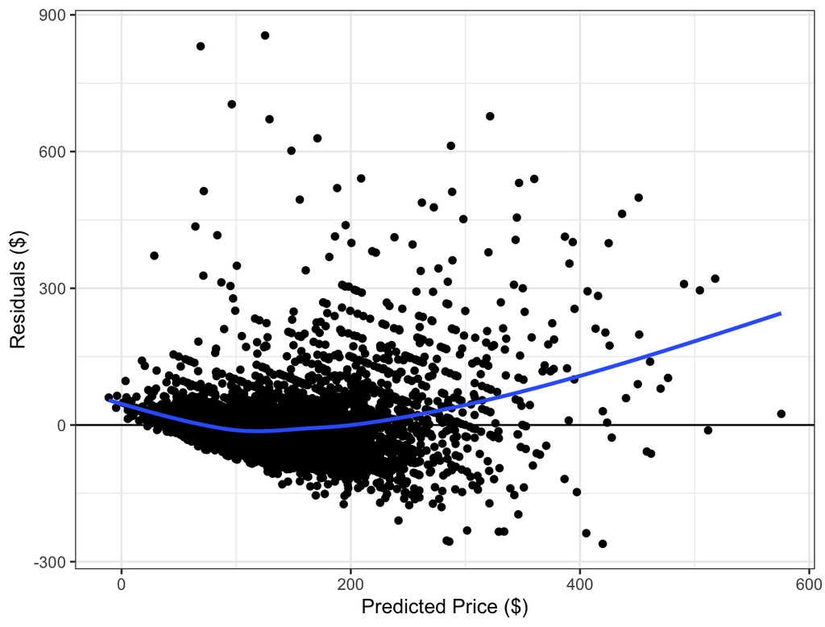

```r
airbnb_final_1_lasso |>
  augment(new_data = airbnb) |>
  mutate(.resid = price - .pred) |>
  ggplot(aes(x = .pred, y = .resid)) +
  geom_point() +
  geom_hline(yintercept = 0) +
  geom_smooth(se = FALSE) +
  labs(y = "Residuals ($)", x = "Predicted Price ($)")
```

# 3. Contributions

Wethu: Early data exploration and the final working code for the prediction model.

Thusa: Early data exploration and ran the first trial-and-error models.

Shona: Code debugging and assistance with the analysis write-up.

# 4. AI Disclosures

We primarily used our in class notes as reference points and prof. Alicia’s advice to complete this project and not AI.